# Red Wine Quality Exploration by Xianglian Ni

# Multivariate Analysis

### Talk about some of the relationships you observed in this part of the investigation. Were there features that strengthened each other in terms of looking at your feature(s) of interest?

> The fixed acidity and pH do not have too much impact on the quality level of various red wine samples. The citric acid and fixed acidity do not affect the overall quality of red wines too.

### Were there any interesting or surprising interactions between features?

> The higher amount of total sulfur dioxide has a negative impact on the quality of red wine. However, the increased ratio of free sulfur dioxide in red wine can help to increase the red wine quality.

### OPTIONAL: Did you create any models with your dataset? Discuss the strengths and limitations of your model.

> No.

# Final Plots and Summary

### Plot One

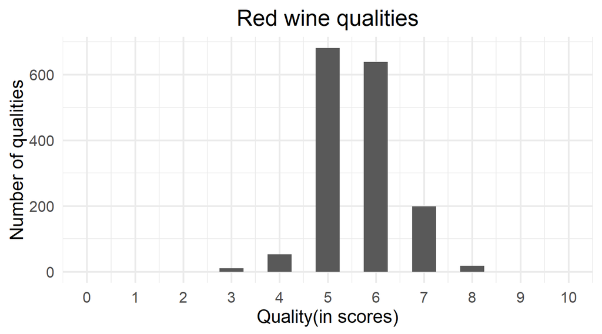

### Description One

> Quality is the most important thing when we buy red wines. So this plot is to show the score of quality and their occurrences. Red wine quality is scored between 0 and 10. From the plot, we can see that most of the red wines are scored at 5 and 6. There is no red wine scored at 0, 1, 2, 9 or 10. Majority of the red wine have a score equal or over 5.

### Plot Two

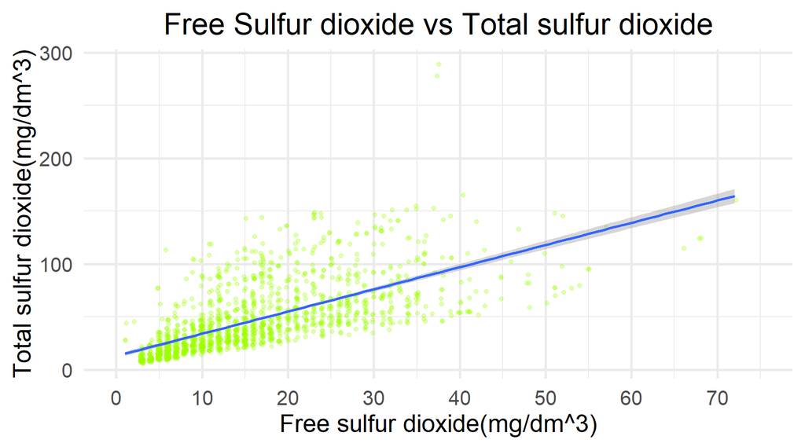

### Description Two

> There is no single chemical property investigated has a strong correlation with red wine quality. But there are some moderate correlation between two properties. For example, this plot shows the free sulfur dioxide in red wine has a positive correlation with total sulfur dioxide. Sulfur dioxide(SO2) is used to prevent microbial growth and the oxidation of wine. With high concentration, SO2 becomes evident in the nose and taste of wine. They potentially have an impact on wine quality. So it is interesting to explore more on this.

### Plot Three

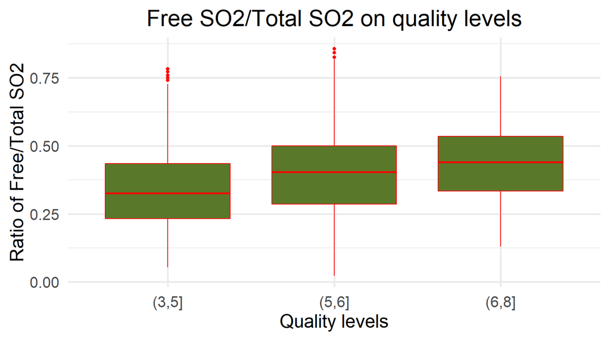

> A categorical variable called quality.level was created by dividing the quality into 3 levels. By creating a categorical variable, I was able to generate a boxplot to show the chemical properties among the different quality levels. Density is defined as the ration of free sulfur dioxide over total sulfur dioxide(SO2). The boxplot shows the density distribution among three red wine quality levels. Higher quality has a larger median value of density.

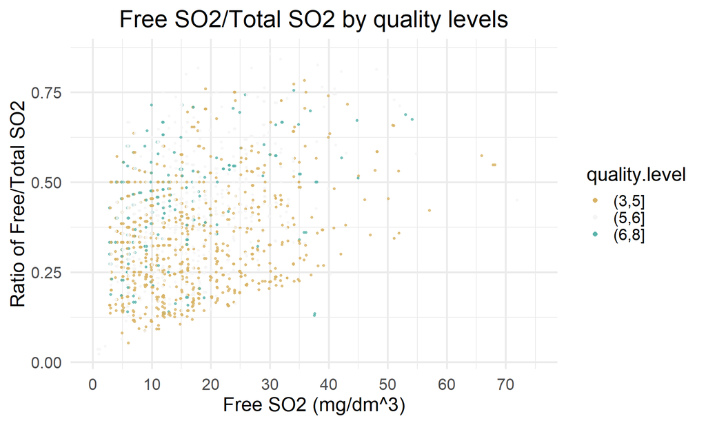

### Description Three

> Hold the free sulfur dioxide(SO2), the higher density of free sulfur dioxide over total sulfur dioxide usually has a higher red wine quality. This might indicate that ratio of free and total sulfur dioxide has an impact on red wine quality. With a larger dataset, there might be a better result to show the trend.

# Reflection

> Drinking red wine appropriately is good to health. There are a lot of brands for red wine in the market. It is hard to choose as it is hard to know their qualities. This dataset provides the opportunity for me to explore a little and get to know the red wine better. There are 12 chemical properties that might be related to the red wine quality. At the frist glance, I would assume that alcohol might decide the quality level. I made the scatterplot of alcohol and quality. It turned out that there is no strong correlation between them. I, therefore, plotted each available chemical property versus quality. None of them shows strong correlation. Then I started plotted scatterplot between two chemical properties. From there, I found that there are some moderate correlation between two properties, such as free sulfur dioxide vs total sulfur dioxide, pH vs fixed acidity, density vs fixed acidity, citric acid vs volatile acidity.

> In order to make a boxplot, I created a categorical variable called quality.level by dividing the quality variable into three levels. Then I was able to further explore the impact of free sulfur dioxide and total sulfur dioxide on red wine quality. It turn out that the median ratio of free sulfur dioxide over total sulfur dioxide is increased with the increased of red wine quality. The scatterplot also shows the same trend.

> It is pretty challenging to predict which property has the most impact on red wine quality. The quality is probably decided by multiple properties. As the wine processing procedure is so complicated and the grapes used to make the wine grow in different climate make it harder to say there is only one or two proeprties can impact the quality. In the future, it will be more interesting to investigate a larger dataset and include additional variable such as the country where the wine is produced.

# References:

> Udacity courses.

> Stackoverflow site: https://stackoverflow.com/questions/40675778/center-plot-title-in-ggplot2